# Step 8 – Complete Your Fishery Management Plan

*How do I take the outputs of the AFAM toolkit to create a concrete Fishery Management Plan?*

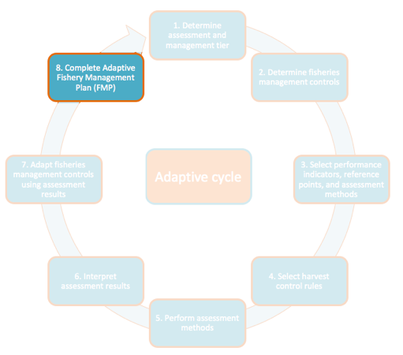

We have provided a template Fishery Management Plan in Appendix 9 – Fishery Management Plan Template. To complete this template, we recommend you use the outputs of the AFAM Dashboard. You may also use outputs from the FLAGS toolkit, the TURF-Reserve Design Survey, Site Level Research Plan, Global Monitoring and Evaluation Plan, and Data Collection Manual to fill out sections of this template. We recommend you complete a fishery management plan for each species to be managed. Note that the template provided here may need to be adapted to better suit your regional context.

# Appendix 9 – Fishery Management Plan Template

- **Fishery Overview:**

  *You may use the outputs of the TURF-Reserve Design Survey and FLAGS toolkit to help complete this section.*
  - **Location of the Fishery**: Country, state, city, management zone (if applicable).
  - **History**: Provide a brief history of the fishery.
  - **Type(s) of Fishery**: Commercial, recreational, etc. and whether near shore, off shore, or mixed.
  - **Participants**: Number of fishers, number of vessels, number of communities (if applicable), and spatial distribution of participants/ communities.
  - **Fishery Characteristics**: Describe the gear types utilized in the fishery (i.e. fixed gear, mobile gear, etc), including numbers for each if possible, as well as the general timeframe (i.e. season) of when the fishery occurs.
  - **Management Characteristics**: Type of method currently used to manage the fishery (i.e. seasons, catch limits, size limits, effort limits, etc.). Also describe the general management decision-making process.
  - **Governance**: Briefly describe key legislation and regulations, as well as types of committees and/or legislative land claims which are part of the decision making process (based on zones, areas, regions, international considerations).
  - **Economic, Social, and Cultural Importance of the Fishery**: Provide a brief overview of economic conditions and social, cultural and economic issues.
  - **Species Characteristics**: Provide a brief overview outlining the main biological characteristics of the species with emphasis on the aspects which impact on management of the species. Factors to be covered include range (both globally and locally), populations/stock structure, habitat requirements (including key location where applicable), migration routes and reproductive characteristics (i.e. season, behavior, fecundity, growth rates, spawning grounds).
  - **Ecosystem Interactions**: Briefly describe interactions with other species and the physical environment. Where the information is available briefly describe the effect of climate regime changes on stock status, particularly recruitment and stock productivity.
- **Fisheries Objectives and Challenges:**

*You may use the outputs of the FLAGS toolkit to help complete this section.*

- **Management Objectives**: Clearly state long-term objectives for fishery management under the following potential headings:
  - **Yield/ Economic**
  - **Stock Conservation**
  - **Ecosystem**
  - **Social and Cultural**
  - **Compliance**
    - For each long-term objective, outline short-term objectives specific for the duration of the plan.
- **List all Trade-Offs Associated with these Objectives**: Provide a brief explanation of which objectives conflict with each other, such that one objective may have to be sacrificed to achieve another. Where possible, discuss potential management modifications that may lessen these trade-offs.
- **Current Management Issues**: Provide an overview of current issues in the fishery, including those related to the target species, as well as by-catch and ecosystem concerns. Potential examples of management issues include:
  - *Fisheries Issues* such as conflicts between gear sectors, catch monitoring, by-catch problems and other resource user issues.
  - *Depleted Species Concerns*, including species listed under CITES, and/ or any local endangered/threatened species legislation. Reference existing recovery strategies/management plans where appropriate.
  - *Oceans and Habitat Considerations*, including habitat impacts and discussions of ecologically significant areas that have been identified and documented within the geographic range of the fishery (including marine protected areas (MPAs) or no-take zones. Where information is available on the effect of climate regime change on stock status, it should be considered when developing harvest decision rules and other management measures. Any management measures in place to control aquatic invasive species should also be included.
  - *Gear Impacts*, including losses and resulting impacts.
  - *International Issues*
- **Science and Traditional Knowledge:**

*You may use your Site Level Research Plan, the Global Monitoring & Evaluation Plan, and the Data Collection Manual to help you complete this section.*

- **Available Data:** Provide brief overview of all available data, with references to sources.
- **Data Collection:** Provide a brief overview of the data collection process for the stock(s), including types of data sources utilized (i.e. research vessel trawl surveys, tagging, index fisheries, CPUE, landing statistics, sentinel fisheries, etc.) and frequency of assessment.
- **Traditional Knowledge:** Provide brief overview of all traditional/ local knowledge.
- **Research:** Provide a brief overview of research projects being conducted during the period of the plan and their purpose. Also include any research needs not currently being addressed. Consider not just the target species, but also research on associated by-catch and habitat.
- **Precautionary Approach (PA)**: Where available, provide a brief overview of any PA references established for this resource, including removal references, limit reference points, and upper stock reference points.
- **Adaptive Assessment and Management:**